# 01. ITS2 preprocessing and method comparison

Cutadapt paired-end vs ITSxpress paired-end

2026-10-15

# 1 1. Dataset

## 1.1 분석 범위

- 입력: `q20_ee22_both_full`의 Cutadapt paired-end 및 ITSxpress paired-end DADA2 feature table과 UNITE v10 99% taxonomy
- 비교 단위: 두 방법에 모두 존재하는 동일 SampleID 83개
- phyloseq level: ASV count, 7개 taxonomy rank 및 동일 metadata
- filtering: taxonomy 정리, `Kingdom == Fungi`, zero-sum sample/taxon 제거만 적용함
- abundance threshold, singleton removal, rarefaction 및 decontam은 적용하지 않음
- PCoA: non-rarefied Species count에 pseudocount 0.5와 CLR을 적용한 Aitchison distance 사용함
- 방법 효과: 동일 SampleID 내 paired permutation을 적용한 PERMANOVA와 `betadisper`로 평가함

## 1.2 Sample info

| Item | N |
| --- | --- |
| Metadata samples | 83 |
| Common samples in both methods | 83 |
| Skin subjects | 2 |
| Skin Subject × Site units | 18 |
| Control sources | 3 |

| Sample_Type | Control_Type | PCR_Cycle_Group | N |
| --- | --- | --- | --- |
| Control | Air swab | PCR1_33__PCR2_8 | 1 |
| Control | Air swab | PCR1_33__PCR2_10 | 1 |
| Control | Air swab | PCR1_35__PCR2_8 | 1 |
| Control | Air swab | PCR1_35__PCR2_10 | 1 |
| Control | Clean bench swab | PCR1_33__PCR2_8 | 1 |
| Control | Clean bench swab | PCR1_33__PCR2_10 | 1 |
| Control | Clean bench swab | PCR1_35__PCR2_8 | 1 |
| Control | Clean bench swab | PCR1_35__PCR2_10 | 1 |
| Control | Empty tube | PCR1_33__PCR2_8 | 1 |
| Control | Empty tube | PCR1_33__PCR2_10 | 1 |

[output cut: 6 more lines]

# 2 2. Phyloseq preprocessing

## 2.1 생성 및 taxonomy 검증

| Method | Stage | Samples | Taxa | Total_Reads |
| --- | --- | --- | --- | --- |
| Cutadapt | Imported ASV table | 83 | 1301 | 954579 |
| Cutadapt | Taxonomy cleaned | 83 | 1301 | 954579 |
| Cutadapt | Kingdom == Fungi retained | 83 | 1301 | 954579 |
| Cutadapt | Zero-sum samples/taxa removed | 83 | 1301 | 954579 |
| ITSxpress | Imported ASV table | 83 | 1215 | 536398 |
| ITSxpress | Taxonomy cleaned | 83 | 1215 | 536398 |
| ITSxpress | Kingdom == Fungi retained | 83 | 1215 | 536398 |
| ITSxpress | Zero-sum samples/taxa removed | 83 | 1215 | 536398 |

| Method | ASV | Kingdom | Phylum | Class | Order | Family | Genus | Species |
| --- | --- | --- | --- | --- | --- | --- | --- | --- |
| Cutadapt | 1301 | 1 | 7 | 27 | 73 | 181 | 299 | 431 |
| ITSxpress | 1215 | 1 | 6 | 30 | 87 | 222 | 394 | 598 |

## 2.2 Sample별 read 및 ASV 비교

| Method | Sample_Type | N | Min | Max | Median | Mean | SD |
| --- | --- | --- | --- | --- | --- | --- | --- |
| Cutadapt | Control | 12 | 220 | 6293 | 1561 | 2115.5 | 1673.3 |
| Cutadapt | True | 71 | 796 | 41132 | 13400 | 13087.2 | 7980 |
| ITSxpress | Control | 12 | 42 | 5998 | 1369.5 | 1660.6 | 1715 |
| ITSxpress | True | 71 | 109 | 16101 | 7453 | 7274.2 | 4101.5 |

| Metric | N_Pairs | Median_Cutadapt | Median_ITSxpress | P_value | P_adjust_BH |
| --- | --- | --- | --- | --- | --- |
| Read depth | 83 | 10834 | 6692 | 3.981308803338158e-14 | 7.962617606676316e-14 |
| Observed ASV | 83 | 43 | 44 | 0.005550678122802304 | 0.005550678122802304 |

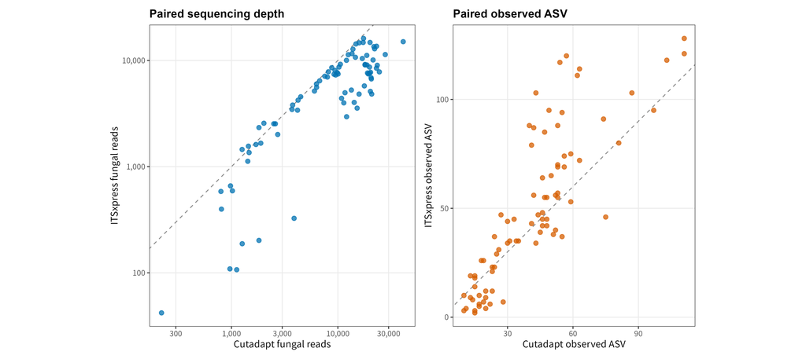

# 3 3. Beta diversity

## 3.1 Aitchison PCoA 및 paired method effect

| Distance | N_Samples | PERMANOVA_R2 | PERMANOVA_P | Betadisper_P | Procrustes_Correlation | PROTEST_P |
| --- | --- | --- | --- | --- | --- | --- |
| Aitchison (Species CLR, pseudocount 0.5) | 83 | 0.08564274868294058 | 0.001 | 0.018 | 0.950256817593193 | 0.001 |

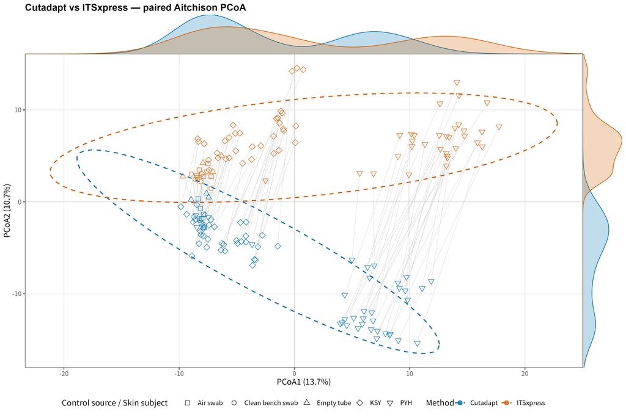

# 4 4. Taxonomic composition

## 4.1 Species overlap 및 paired abundance difference

- Spearman plot의 각 점은 sample 또는 ASV가 아니라, 동일 Species label로 집계한 뒤 83개 sample의 relative abundance를 평균한 Species-level taxon임.
- 분홍색으로만 표시하던 주요 taxon은 RColorBrewer `Paired`와 `Dark2` 기반의 고정 색상을 적용하고 Species 이름을 직접 표시함.
- 표는 전체 Species overlap과 Top 14 Species의 paired abundance difference를 유지함.

| Item | N |
| --- | --- |
| Cutadapt detected Species | 431 |
| ITSxpress detected Species | 598 |
| Shared Species | 343 |
| Cutadapt only | 88 |
| ITSxpress only | 255 |

| Species | N_Pairs | Mean_Cutadapt | Mean_ITSxpress | Mean_Difference_ITSxpress_minus_Cutadapt | P_value | P_adjust_BH | Significant |
| --- | --- | --- | --- | --- | --- | --- | --- |
| Fungi k | 83 | 0.1352084283964702 | 0.002042701589386071 | -0.1331657268070841 | 5.804029703247485e-15 | 8.125641584546479e-14 | *** |
| Aureobasidium tremulum | 83 | 0.2335763184443253 | 0 | -0.2335763184443253 | 7.813397835134488e-13 | 5.469378484594142e-12 | *** |
| Malassezia restricta | 83 | 0.2761919569292295 | 0.3787070227140068 | 0.1025150657847772 | 5.837972573764954e-12 | 2.724387201090312e-11 | *** |
| Cutaneotrichosporon debeurmannianum | 83 | 0.03171382379055958 | 0.0735867225576379 | 0.04187289876707833 | 1.456180596759758e-11 | 5.096632088659152e-11 | *** |
| Fungi sp | 83 | 0.0009544179057084974 | 0.03337327997576819 | 0.03241886207005969 | 5.282724865618042e-11 | 1.479162962373052e-10 | *** |
| Nigrospora sp | 83 | 6.41396497331039e-05 | 0.02855867512008716 | 0.02849453547035406 | 7.75514624681561e-11 | 1.551029249363122e-10 | *** |
| Pleosporales sp | 83 | 0.002908503480011844 | 0.01669701166224822 | 0.01378850818223638 | 7.75514624681561e-11 | 1.551029249363122e-10 | *** |
| Alternaria g | 83 | 0.010774907509829 | 0.0328200999755612 | 0.02204519246573221 | 1.979137158731911e-10 | 3.463490027780845e-10 | *** |
| Rhodotorula mucilaginosa | 83 | 0.01782018518648257 | 0.04374217618120342 | 0.02592199099472085 | 1.077936197547889e-09 | 1.67678964063005e-09 | *** |
| Malassezia dermatis | 83 | 0.01311741818910338 | 0.0267220949993495 | 0.01360467681024612 | 2.943081647596504e-07 | 4.120314306635106e-07 | *** |

[output cut: 4 more lines]

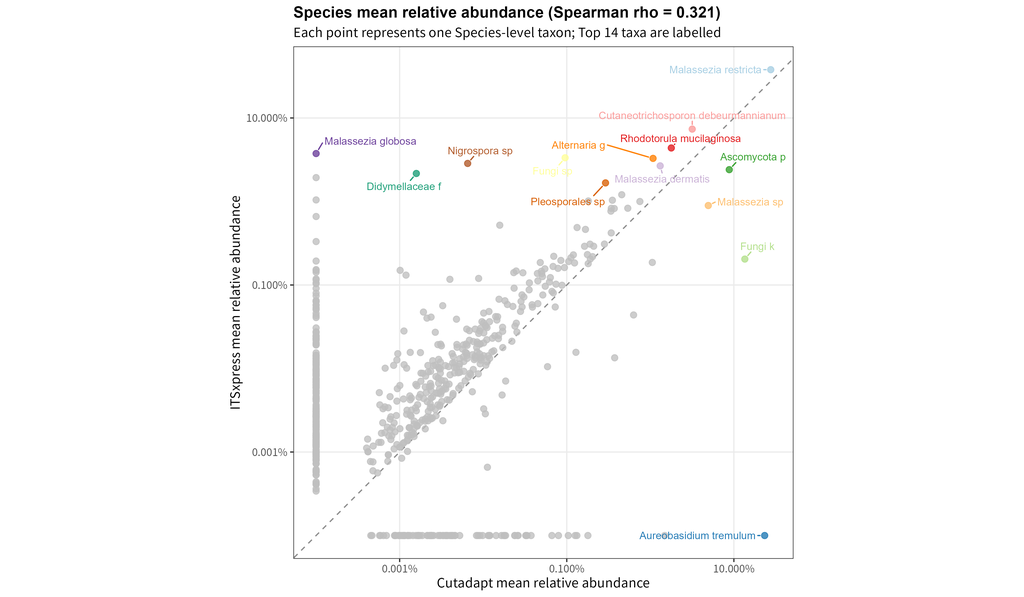

## 4.2 Sample별 Species composition

- 각 막대는 개별 SampleID 한 개이며 sample 평균으로 합치지 않음.
- Cutadapt와 ITSxpress를 각각 독립된 큰 panel로 제시하고, 내부에서 Skin subject 또는 control source와 PCR cycle 조건을 분리함.
- 두 방법에 동일한 Species 순서와 RColorBrewer 기반 색상을 적용함.
- HTML에는 전체 그림을 축소한 preview를 표시하며, SampleID와 taxon을 확대해서 볼 수 있는 고해상도 원본은 `Results/01_Preprocessing`에 별도로 저장함.

### 4.2.1 Cutadapt

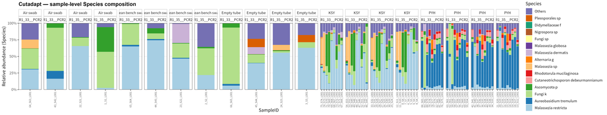

Cutadapt 고해상도 PNG 원본 열기

### 4.2.2 ITSxpress

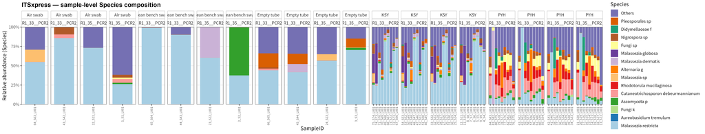

ITSxpress 고해상도 PNG 원본 열기

## 4.3 ASV sequence pattern 및 method 간 frequency 비교

- `Fungi_k`와 `Ascomycota_p`는 실제 Species명이 아니라 각각 Kingdom 또는 Phylum까지만 분류된 ASV에 부여한 fallback label임.
- 따라서 두 label 내부의 ASV 길이, adapter motif, prevalence와 abundance를 개별 서열 수준에서 다시 확인함.
- Cutadapt와 ITSxpress는 trimming 경계가 다르므로 완전 동일 서열뿐 아니라, 길이 100 bp 이상인 한쪽 ASV가 다른 쪽 ASV에 완전히 포함되는 exact-containment도 함께 평가함.
- 전체 재현 코드는 05_unresolved_taxa_diagnostic.R에 저장함.

### 4.3.1 미분류 ASV 길이와 Nextera motif

| Method | Taxon_Group | N_ASV | Median_Length | Q1_Length | Q3_Length | Min_Length | Max_Length | Median_GC | Median_Entropy | Nextera_full_ASV | Nextera_12mer_ASV | Total_Reads |
| --- | --- | --- | --- | --- | --- | --- | --- | --- | --- | --- | --- | --- |
| Cutadapt | Ascomycota_p | 111 | 296 | 86 | 356 | 36 | 418 | 55.48961424332344 | 0.9856646199733524 | 0 | 5 | 83076 |
| Cutadapt | Fungi_k | 329 | 109 | 69 | 278 | 33 | 399 | 49.09090909090909 | 0.9775937918585133 | 0 | 6 | 71631 |
| Cutadapt | Other_fungal_ASV | 861 | 346 | 314 | 362 | 125 | 516 | 47.6038338658147 | 0.9928162645527472 | 0 | 0 | 799872 |
| ITSxpress | Ascomycota_p | 22 | 164 | 150 | 172 | 140 | 222 | 63.74634642267124 | 0.9684323444299134 | 0 | 0 | 11160 |
| ITSxpress | Fungi_k | 18 | 214.5 | 176 | 240.5 | 74 | 244 | 45.67478555346743 | 0.9891214168962428 | 0 | 0 | 1382 |
| ITSxpress | Other_fungal_ASV | 1175 | 191 | 161 | 208 | 56 | 369 | 50 | 0.9839532813618428 | 0 | 0 | 523856 |

| Method | Taxon_Group | N_Group | P_Wilcoxon_vs_other_fungal | P_adjust_BH |
| --- | --- | --- | --- | --- |
| Cutadapt | Fungi_k | 329 | 7.289773236688629e-92 | 2.915909294675452e-91 |
| Cutadapt | Ascomycota_p | 111 | 2.501558167576093e-11 | 5.003116335152187e-11 |
| ITSxpress | Fungi_k | 18 | 0.05507529014807048 | 0.05507529014807048 |
| ITSxpress | Ascomycota_p | 22 | 0.00123203768490473 | 0.00164271691320631 |

- Cutadapt의 `Fungi_k`는 median 109 bp로, 분류된 다른 fungal ASV의 median 346 bp보다 현저히 짧음.
- Nextera 12-mer를 포함한 미분류 ASV는 11개, 합계 113 reads이며 모두 최대 prevalence 1 sample임. 완전한 19-mer Nextera sequence를 포함한 ASV는 0개임.
- 따라서 일부 짧은 ASV는 adapter-related artifact로 보이지만, 해당 reads 수가 작아 `Fungi_k`/`Ascomycota_p` 전체 abundance를 단독으로 설명하지는 못함.

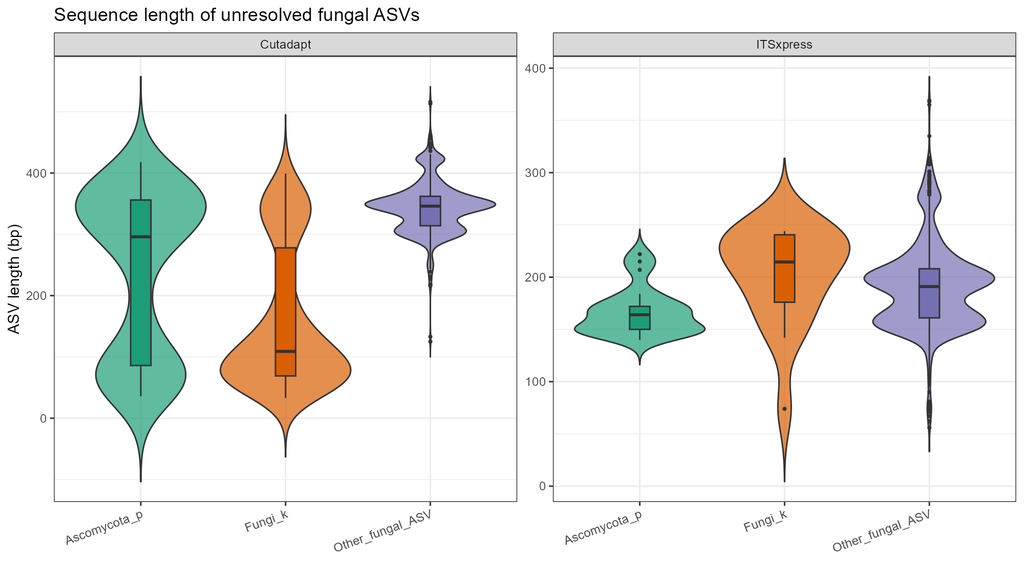

### 4.3.2 Nextera 비율과 미분류 taxon abundance

| Method | Taxon_Group | Nextera_Metric | Stratum | N | Spearman_rho | P_value | P_adjust_BH |
| --- | --- | --- | --- | --- | --- | --- | --- |
| Cutadapt | Ascomycota_p | Cleanup_match_percent | All samples | 83 | -0.01326560597791864 | 0.9052533435219996 | 0.9071770104178432 |
| Cutadapt | Ascomycota_p | Cleanup_match_percent | True only | 71 | 0.05962441314553989 | 0.6213581769347472 | 0.7456298123216966 |
| Cutadapt | Ascomycota_p | Raw_FastQC_percent | All samples | 83 | 0.08565971201880691 | 0.4413125598652886 | 0.5884167464870514 |
| Cutadapt | Ascomycota_p | Raw_FastQC_percent | True only | 71 | 0.1881623071763917 | 0.1160866507979605 | 0.1857386412767369 |
| Cutadapt | Fungi_k | Cleanup_match_percent | All samples | 83 | 0.4175937198270433 | 8.572113444191846e-05 | 0.0006857690755353476 |
| Cutadapt | Fungi_k | Cleanup_match_percent | True only | 71 | 0.2387323943661972 | 0.0449650562839648 | 0.09658468239010598 |
| Cutadapt | Fungi_k | Raw_FastQC_percent | All samples | 83 | 0.3866966122329037 | 0.0003049044037500534 | 0.00146354113800025 |
| Cutadapt | Fungi_k | Raw_FastQC_percent | True only | 71 | 0.192823608316566 | 0.1071622754097782 | 0.183706757845334 |
| ITSxpress | Ascomycota_p | Cleanup_match_percent | All samples | 83 | -0.3536524670943976 | 0.00103903907058048 | 0.00415615628232193 |
| ITSxpress | Ascomycota_p | Cleanup_match_percent | True only | 71 | -0.2352394309918071 | 0.04829234119505299 | 0.09658468239010598 |

[output cut: 6 more lines]

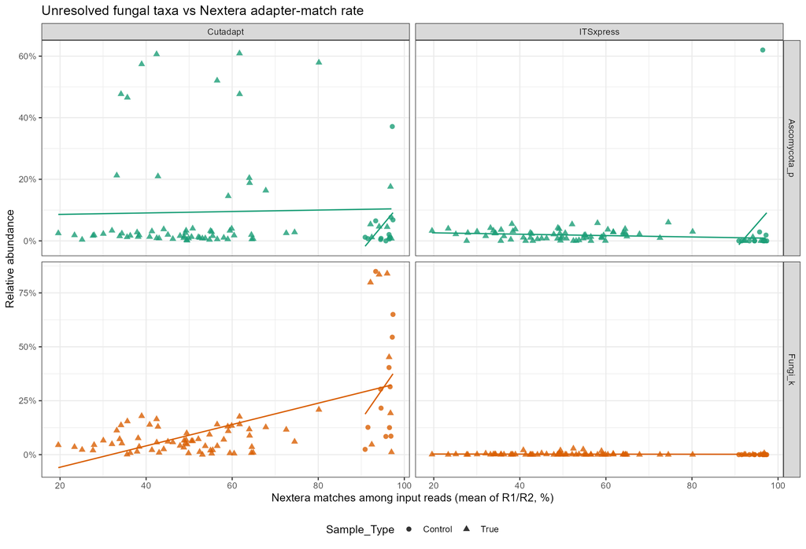

- 전체 sample에서는 Cutadapt `Fungi_k`와 raw/cleanup Nextera 지표가 양의 상관을 보이지만, True sample만 제한하면 BH 보정 후 유의하지 않음.
- ITSxpress에서는 같은 `Fungi_k` 관계가 반대 방향이므로, Nextera 비율이 특정 biological taxon을 직접 증가시킨다고 해석하기보다 sample type, 짧은 insert와 trimming method가 함께 만든 연관으로 해석함.

### 4.3.3 Cutadapt–ITSxpress ASV sequence frequency

| Metric | Value |
| --- | --- |
| Cutadapt ASVs | 1301 |
| ITSxpress ASVs | 1215 |
| Exact-identical ASV pairs | 0 |
| ITSxpress ASVs with &gt;=100-bp exact containment match | 740 |
| Matched ITSxpress ASV read fraction | 0.9526787944772352 |
| Matched ITSxpress ASV frequency vs Cutadapt frequency Spearman rho | 0.9306870119700164 |

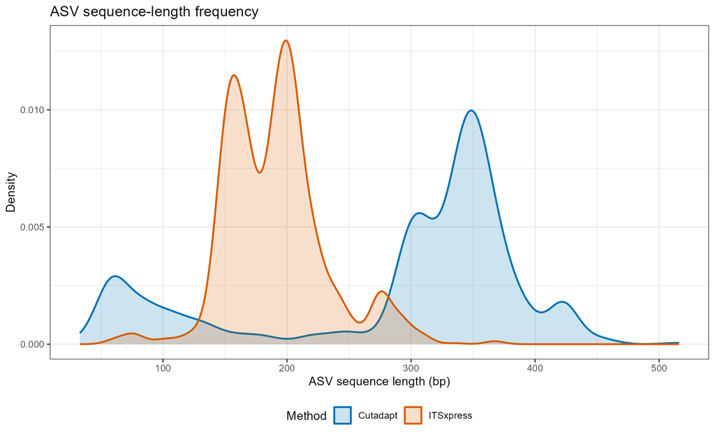

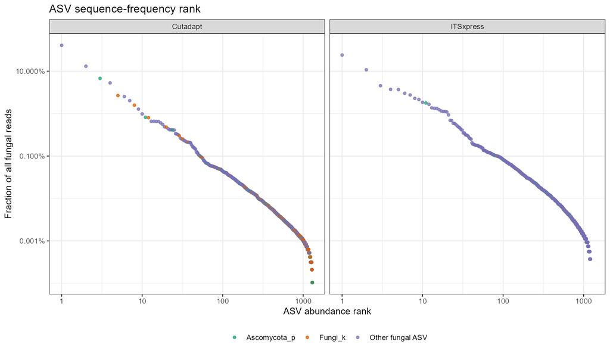

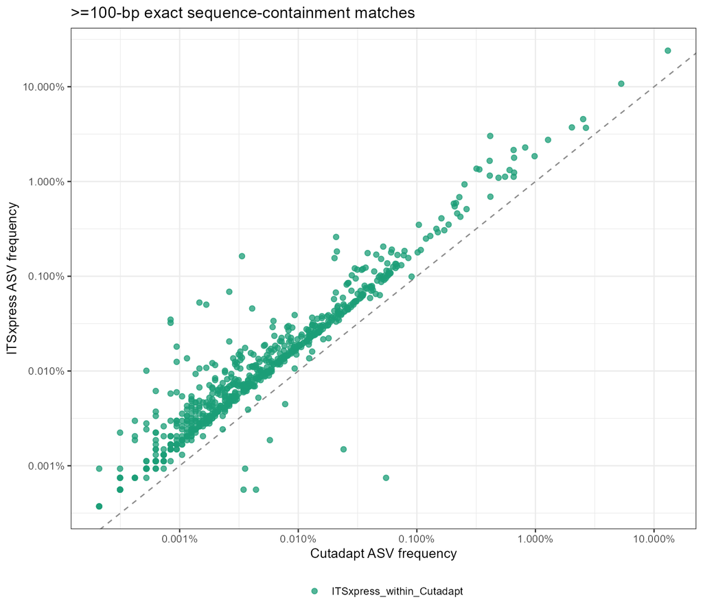

- 완전 동일한 ASV sequence pair가 없는 것은 두 방법의 trimming 경계 차이와 일치함.
- ITSxpress ASV 중 100 bp 이상 exact-containment로 Cutadapt ASV에 대응되는 서열은 740개이며, 이들이 ITSxpress fungal read의 95.3%를 차지함.
- 대응 ASV의 전체 read frequency 순위상관은 Spearman rho 0.931로, 주요 서열의 abundance ordering은 두 방법에서 매우 유사함.

## 4.4 PYH의 Aureobasidium 우점과 농도 관계

- 핵심 질문은 부위별 차이가 아니라, Cutadapt에서 `Aureobasidium tremulum`이 PYH library에 집중된 이유와 이것이 농도 의존적인지 여부임.
- 동일 SampleID의 Cutadapt–ITSxpress 차이와 함께, Cutadapt `A. tremulum` relative abundance 및 raw reads가 Qubit과 연관되는지 확인함.
- `Qubit_ng_uL`은 PCR 이후 library QC 값이므로 추출 직후 fungal biomass나 starting DNA 농도와 동일하게 해석하지 않음.
- KSY와 PYH는 각각 한 대상자이므로 아래 결과는 이 두 대상자의 기술적·생물학적 차이에 대한 기술적 분석이며 일반적인 subject effect 검정이 아님.
- 기존 계산의 전체 재현 코드는 06_subject_method_discrepancy.R에 저장함.

### 4.4.1 Subject 및 library Qubit

| Subject | N | Qubit_Median | Qubit_IQR | Aitchison_Median | Aitchison_IQR | Bray_Median | Bray_IQR | Species_L1_Median | ITSxpress_Read_Recovery_Median | Nextera_Median |
| --- | --- | --- | --- | --- | --- | --- | --- | --- | --- | --- |
| KSY | 35 | 50 | 8.700000000000003 | 20.39522992367642 | 7.536192970607974 | 0.4407537458681131 | 0.451934984845024 | 0.440753745868113 | 0.8547476759628154 | 53.74320788891125 |
| PYH | 36 | 31.3 | 14.375 | 28.56784514027068 | 6.253611395462695 | 0.7274457616764785 | 0.2211252857576942 | 0.7274457616764785 | 0.47683937134552 | 49.21703509764279 |

| Metric | P_Wilcoxon_KSY_vs_PYH | P_adjust_BH |
| --- | --- | --- |
| Qubit_ng_uL | 1.503048775454321e-06 | 9.018292652725928e-06 |
| Aitchison_Method_Distance | 0.0004616362812199375 | 0.0006924544218299063 |
| Bray_Method_Distance | 0.0001312435516569428 | 0.0002624871033138856 |
| Species_L1_Difference | 0.0001312435516569428 | 0.0002624871033138856 |
| Log2_ITSxpress_Cutadapt_Read_Ratio | 0.00141510042161611 | 0.00169812050593933 |
| Nextera_percent | 0.4174650082937052 | 0.4174650082937052 |

| Stratum | N | Qubit_vs_Aitchison_rho | P_value | P_adjust_BH |
| --- | --- | --- | --- | --- |
| All True samples | 71 | 0.04456809145604104 | 0.7120866565994606 | 0.7120866565994606 |
| KSY | 35 | -0.1303617781187022 | 0.4554163764154339 | 0.6831245646231507 |
| PYH | 36 | 0.7039063017343244 | 1.670356506713606e-06 | 5.011069520140817e-06 |

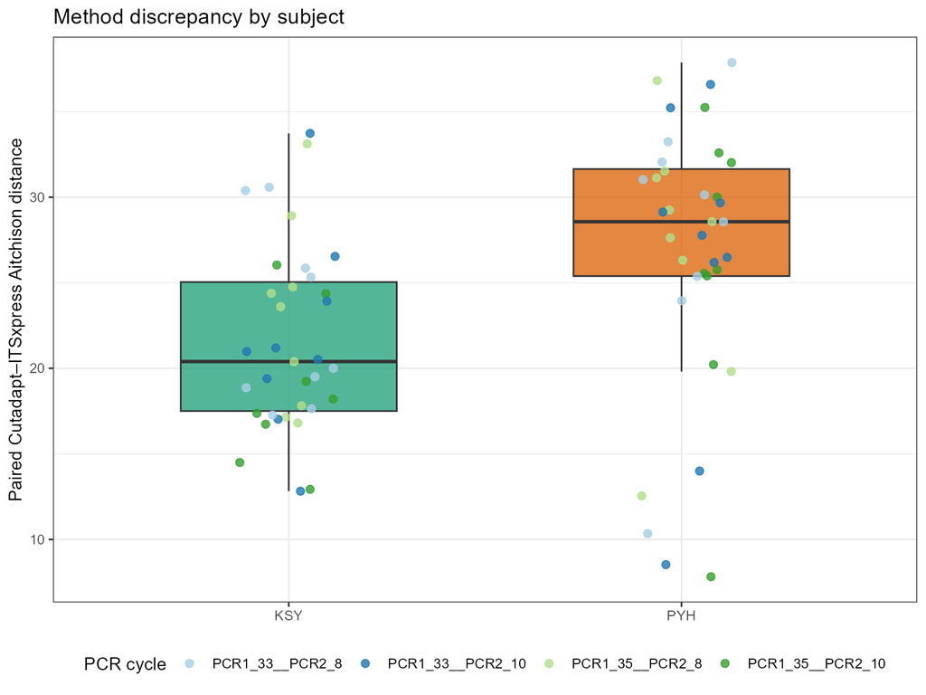

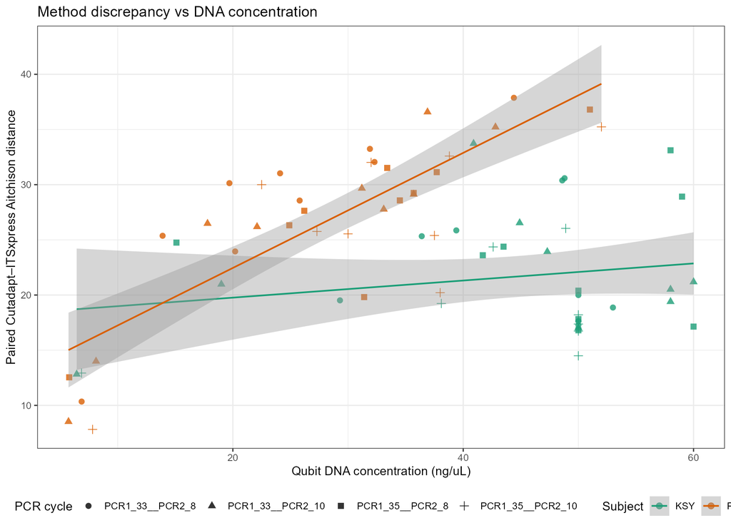

- PYH의 paired Aitchison distance median은 28.6으로 KSY의 20.4보다 크며, Bray distance도 각각 0.727과 0.441로 차이가 확인됨.
- ITSxpress/Cutadapt fungal read 회수율 median은 PYH 0.477, KSY 0.855로, PYH에서 ITSxpress 단계 후 보존되는 fungal reads가 더 적음.
- 전체 True sample에서 Qubit과 method distance의 상관은 rho 0.045, p = 0.712로 확인되어 낮은 library 농도가 전체 차이를 직접 설명하지 않음.

### 4.4.2 Aureobasidium abundance와 Qubit

| Subject | N_Libraries | Detected_Libraries | Mean_RA | Median_RA | Median_Raw_Reads | Median_Qubit |
| --- | --- | --- | --- | --- | --- | --- |
| KSY | 35 | 25 | 0.009538028984170329 | 0.003887634813142714 | 37 | 50 |
| PYH | 36 | 36 | 0.5234856051271822 | 0.5890709792066986 | 11242 | 31.3 |

| Subject | N | Spearman_rho | P_value | Metric | P_adjust_BH |
| --- | --- | --- | --- | --- | --- |
| KSY | 35 | 0.3126019085785118 | 0.06749877496004388 | Relative abundance vs Qubit | 0.08999836661339183 |
| KSY | 35 | 0.2683107501331752 | 0.1191310687813795 | Raw reads vs Qubit | 0.1361497928930051 |
| KSY | 35 | -0.7040293914458604 | 2.370910607891599e-06 | Relative abundance vs total fungal reads | 9.483642431566397e-06 |
| KSY | 35 | -0.1767035365666051 | 0.3098936475239883 | Relative abundance vs Nextera percent | 0.3098936475239883 |
| PYH | 36 | 0.4578158192117374 | 0.004990931084332142 | Relative abundance vs Qubit | 0.009981862168664283 |
| PYH | 36 | 0.5630992997051872 | 0.000349660607277684 | Raw reads vs Qubit | 0.0009324282860738239 |
| PYH | 36 | 0.7106821106821107 | 1.195212210472103e-06 | Relative abundance vs total fungal reads | 9.483642431566397e-06 |
| PYH | 36 | -0.4061776061776062 | 0.01396887843220392 | Relative abundance vs Nextera percent | 0.02235020549152628 |

| Subject | PCR_Cycle_Group | N | Median_RA | Median_Raw_Reads | Median_Qubit |
| --- | --- | --- | --- | --- | --- |
| KSY | PCR1_33__PCR2_10 | 9 | 0.008146253670550345 | 31 | 47.3 |
| KSY | PCR1_33__PCR2_8 | 9 | 0.004701492537313433 | 39 | 48.8 |
| KSY | PCR1_35__PCR2_10 | 8 | 0 | 0 | 49.45 |
| KSY | PCR1_35__PCR2_8 | 9 | 0.003887634813142714 | 37 | 50 |
| PYH | PCR1_33__PCR2_10 | 9 | 0.5873768308921438 | 11028 | 31.2 |
| PYH | PCR1_33__PCR2_8 | 9 | 0.5166460432502504 | 10851 | 24.1 |
| PYH | PCR1_35__PCR2_10 | 9 | 0.6337441705529647 | 11608 | 32 |
| PYH | PCR1_35__PCR2_8 | 9 | 0.5907651275212535 | 11069 | 33.4 |

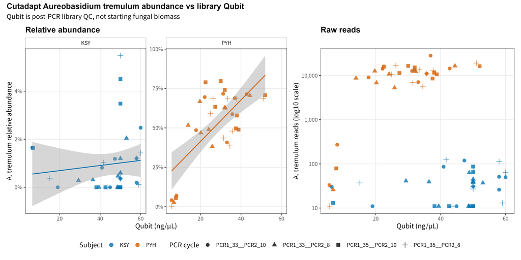

### 4.4.3 Cutadapt–ITSxpress 차이에서 Aureobasidium의 기여

| Subject | Species | Cutadapt | ITSxpress | ITSxpress_minus_Cutadapt |
| --- | --- | --- | --- | --- |
| PYH | Aureobasidium tremulum | 0.5234856051271822 | 0 | -0.5234856051271822 |
| PYH | Cutaneotrichosporon debeurmannianum | 0.07228187083671933 | 0.1646250525980728 | 0.09234318176135342 |
| PYH | Fungi sp | 0.00140484106331849 | 0.07287572664990526 | 0.07147088558658676 |
| PYH | Rhodotorula mucilaginosa | 0.03945551947429586 | 0.0974005469039778 | 0.05794502742968194 |
| PYH | Didymellaceae f | 0 | 0.04359142983352216 | 0.04359142983352216 |
| PYH | Alternaria g | 0.02047453262633988 | 0.06330525313212393 | 0.04283072050578405 |
| PYH | Cladosporium g | 0 | 0.02881112687738163 | 0.02881112687738163 |
| PYH | Malassezia dermatis | 0.00387490244535159 | 0.0279233507354484 | 0.02404844829009681 |
| PYH | Curvularia g | 0.00390003039085666 | 0.02103408347003958 | 0.01713405307918292 |
| PYH | Periconia celtidis | 0.00477900533582753 | 0.01811264649376027 | 0.01333364115793274 |

[output cut: 5 more lines]

| Subject | N | Tremulum_vs_Aitchison_rho | Tremulum_vs_Aitchison_P | Tremulum_vs_ReadRecovery_rho | Tremulum_vs_ReadRecovery_P | Tremulum_vs_Qubit_rho | Tremulum_vs_Qubit_P |
| --- | --- | --- | --- | --- | --- | --- | --- |
| KSY | 35 | -0.3875574759500118 | 0.02143255986393857 | 0.578998115806855 | 0.0002683754843848093 | 0.3126019085785118 | 0.06749877496004388 |
| PYH | 36 | 0.6301158301158302 | 3.81627451007508e-05 | -0.648906048906049 | 1.86229085952935e-05 | 0.4578158192117374 | 0.00499093108433214 |

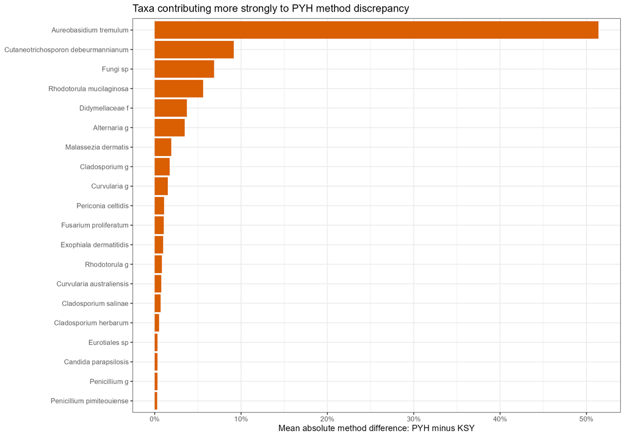

- `Aureobasidium tremulum`은 KSY에서도 검출되지만 Cutadapt 평균 relative abundance가 약 0.95%인 반면, PYH에서는 52.3%로 매우 높음. 따라서 “PYH에서만 존재”라기보다 **PYH에서 우점**한 경우임.
- 이 taxon의 Cutadapt 대표 ASV는 303 bp, 387,357 reads, prevalence 64 sample로 짧은 low-frequency artifact가 아님.
- 해당 대표 ASV는 ITSxpress ASV와 100 bp 이상 exact-containment match가 없어 ITSxpress trimming/recognition 단계에서 보존되지 않았을 가능성이 큼.
- PYH 내부에서 Cutadapt `A. tremulum` relative abundance와 Qubit의 상관은 rho = 0.458, p = 0.005로 **양의 방향**임. 낮은 Qubit library일수록 이 taxon이 증가하는 패턴은 관찰되지 않음.
- PYH에서 `A. tremulum` abundance는 method distance와 양의 상관(rho = 0.630), ITSxpress/Cutadapt read 회수율과 음의 상관(rho = -0.649)을 보임. 이는 이 taxon이 많은 library에서 ITSxpress 결과와의 차이가 커진다는 뜻임.
- 다만 Qubit은 PCR 이후 전체 library 농도이며 fungal starting biomass의 직접 측정치가 아니므로, 양의 상관 역시 원인관계로 해석하지 않음.
- 현재 자료에서 가장 보수적인 결론은 **낮은 농도가 만든 artifact라는 근거는 없고**, 두 대상자 중 PYH의 실제 community에서 우점한 Cutadapt ASV가 ITSxpress에서 보존되지 않아 방법 차이가 확대됐다는 것임. 대상자가 각 1명이므로 host-specific biology와 batch를 분리할 수는 없음.

## 4.5 ITS2 경계 trimming과 taxonomy resolution 검증

- Cutadapt의 `Fungi_k`/`Ascomycota_p` ASV 중 ITSxpress ASV가 100 bp 이상 정확히 내부에 포함되는 쌍을 대상으로 함.
- 정확 포함 시작·종료 좌표, 좌우 flanking 길이, ITSxpress 구간이 Cutadapt ASV에서 차지하는 비율과 taxonomy rank 변화를 계산함.
- `Fungi_sp`, `Pleosporales_sp`, `*_Incertae_sedis`처럼 이름만 더 긴 placeholder는 분류 개선으로 세지 않고, 실제로 정보가 추가된 가장 낮은 rank를 기준으로 판정함.
- 대표 쌍은 `Biostrings`/`DECIPHER`로 정렬하고 `ape`/`phangorn`의 GTR+Gamma maximum-likelihood tree로 보조 확인함.
- 전체 재현 코드는 07_ITS2_boundary_taxonomy_analysis.R에 저장함.

### 4.5.1 정확 포함 좌표와 flanking 길이

| Cutadapt_Group | Matched_Cutadapt_ASVs | Classification_Improved_ASVs | Improvement_Percent | Median_Cutadapt_Length_bp | Median_ITSxpress_Length_bp | Median_Total_Flank_bp | Median_ITS_Fraction_Percent | Cutadapt_Reads_in_Matched_ASVs | Improved_ASV_Cutadapt_Reads |
| --- | --- | --- | --- | --- | --- | --- | --- | --- | --- |
| Ascomycota_p | 20 | 9 | 45 | 301 | 153 | 148 | 51.08451589725167 | 13745 | 12748 |
| Fungi_k | 8 | 1 | 12.5 | 367 | 223 | 147.5 | 60.76294277929155 | 27012 | 86 |

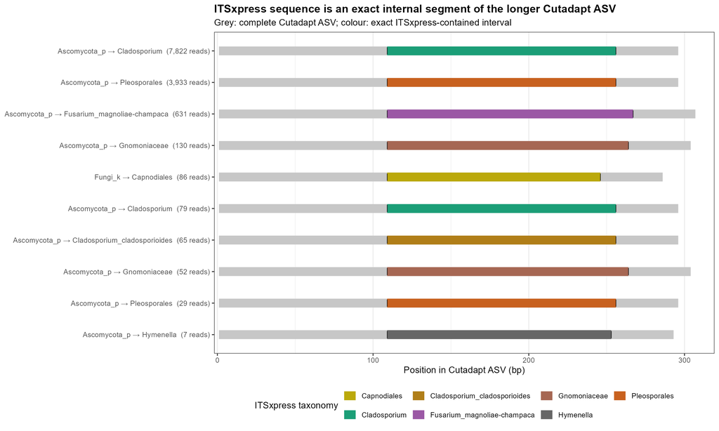

- `Ascomycota_p` matched ASV의 길이 중앙값은 Cutadapt 301 bp, ITSxpress 153 bp이며, 제거된 양쪽 flanking region의 합은 중앙값 148 bp임.
- 즉 ITSxpress ASV는 대응 Cutadapt ASV 길이의 중앙값 51.1%를 차지하며, 그림에서 동일 core sequence가 Cutadapt 긴 ASV 내부에 정확히 위치함.
- 대표적인 동일 core sequence의 taxonomy는 `Ascomycota_p → Cladosporium`, `Ascomycota_p → Pleosporales`, `Ascomycota_p → Fusarium magnoliae-champaca`로 개선됨.

### 4.5.2 분류 rank 개선

| Cutadapt_ASV | Cutadapt_Group | Cutadapt_Length_bp | ITSxpress_ASV | ITSxpress_Length_bp | Left_Flank_bp | Right_Flank_bp | ITSxpress_Deepest_Rank | ITSxpress_Deepest_Label | Cutadapt_Total_Reads | ITSxpress_Total_Reads |
| --- | --- | --- | --- | --- | --- | --- | --- | --- | --- | --- |
| 8f494d0053 | Ascomycota_p | 296 | e399dc7c08 | 148 | 108 | 40 | Genus | Cladosporium | 7822 | 12256 |
| e462722cb5 | Ascomycota_p | 296 | c4882dc60b | 148 | 108 | 40 | Order | Pleosporales | 3933 | 6186 |
| ba665ed805 | Ascomycota_p | 307 | 36387d18f1 | 159 | 108 | 40 | Species | Fusarium_magnoliae-champaca | 631 | 655 |
| d38ccf31fd | Ascomycota_p | 304 | a289d8823d | 156 | 108 | 40 | Family | Gnomoniaceae | 130 | 135 |
| ef659e2e55 | Fungi_k | 286 | 7768765065 | 138 | 108 | 40 | Order | Capnodiales | 86 | 87 |
| e7d9d65002 | Ascomycota_p | 296 | c42377eaad | 148 | 108 | 40 | Genus | Cladosporium | 79 | 160 |
| b7e8d927c2 | Ascomycota_p | 296 | a93ef8ac36 | 148 | 108 | 40 | Species | Cladosporium_cladosporioides | 65 | 67 |
| 8138319382 | Ascomycota_p | 304 | d763d4861e | 156 | 108 | 40 | Family | Gnomoniaceae | 52 | 59 |
| c9beb38843 | Ascomycota_p | 296 | c4882dc60b | 148 | 108 | 40 | Order | Pleosporales | 29 | 6186 |
| bccfc0349b | Ascomycota_p | 293 | c4a2240c5d | 145 | 108 | 40 | Genus | Hymenella | 7 | 6 |

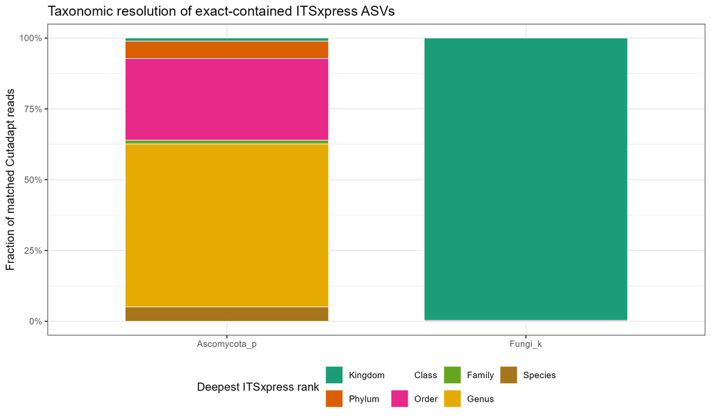

- `Ascomycota_p`는 exact-containment 20개 중 9개(45%)가 실제로 더 낮은 taxonomy rank까지 개선됨. 이 9개는 matched Cutadapt reads의 92.7%를 차지하여, abundance가 큰 `Ascomycota_p` 서열에서 ITS2 경계 정리가 분류에 유리했다는 근거가 강함.
- 반면 `Fungi_k`는 8개 중 1개(12.5%)만 `Capnodiales`까지 개선됐고, matched reads 중 0.32%에 불과함. 따라서 이 기전은 일부 `Fungi_k`에도 존재하지만 `Fungi_k` 전체의 주된 설명은 아님.

### 4.5.3 대표 ASV alignment 및 maximum-likelihood tree

| Representative_Pairs | Tree_Tips | Alignment_Columns | Model | Log_Likelihood |
| --- | --- | --- | --- | --- |
| 9 | 18 | 308 | GTR+Gamma | -1194.577354124261 |

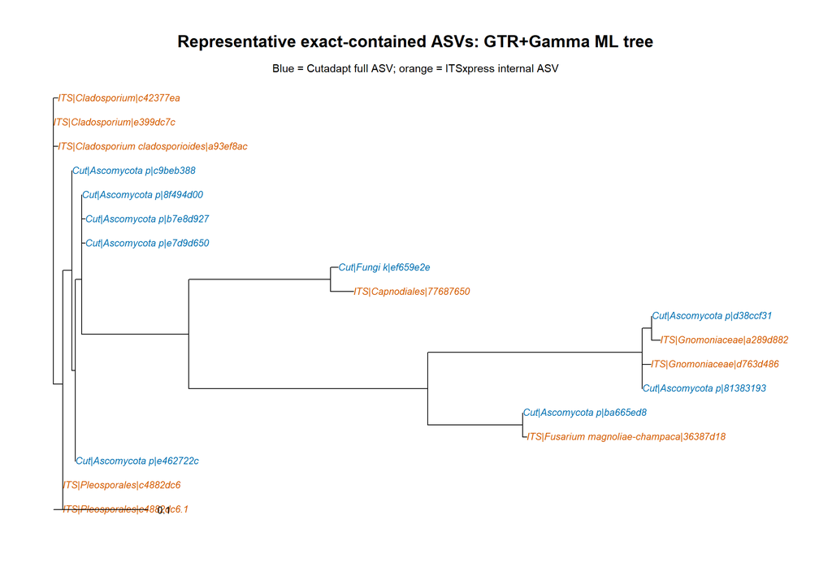

- 대표 9쌍의 Cutadapt full ASV와 ITSxpress internal ASV를 함께 정렬한 결과, 동일 core를 공유하는 쌍들이 가까운 위치에 놓이는 패턴을 확인함.
- 다만 full-length와 internal fragment가 혼재한 tree이므로 계통학적 관계나 새로운 taxonomic assignment의 독립적 증명으로 사용하지 않음. 이 분석의 직접 근거는 tree가 아니라 exact-containment 좌표와 동일 서열에 대한 UNITE taxonomy 변화임.
- 정확 포함 관계만으로 제거된 부분을 모두 ITS1·5.8S 또는 특정 flanking region이라고 확정할 수는 없음. 따라서 현재 결과는 **경계가 정리되지 않은 유효 fungal sequence가 classifier 입력에서 불리했을 가능성과 일치**하며, 전체 `Fungi_k`/`Ascomycota_p`가 불량 서열이었다는 뜻은 아님.

## 4.6 서열 길이 100 bp 이하의 짧은 ASV profile

- 여기서 `ASV 100 이하`는 누적 read 수가 아니라 대표 **서열 길이가 100 bp 이하인 ASV**를 뜻함.
- 이 기준은 filtering rule이 아니며, 짧은 서열이 Cutadapt와 ITSxpress에서 얼마나 생성되고 어느 sample과 taxonomy에 분포하는지 진단하기 위한 표시 기준임.
- ASV 수, 전체 read 기여도, 실제 길이 분포, abundance/prevalence, taxonomy 및 sample별 기여율을 함께 비교함.

### 4.6.1 전체 규모와 read 수가 많은 짧은 ASV

| Method | All_ASVs | Short_ASVs | Short_ASV_percent | All_Reads | Short_ASV_Reads | Short_read_percent | Prevalence_1_Short_ASVs | Median_short_ASV_reads | Median_short_ASV_prevalence | Median_short_ASV_length | Nextera_12mer_Short_ASVs | Nextera_12mer_Short_Reads |
| --- | --- | --- | --- | --- | --- | --- | --- | --- | --- | --- | --- | --- |
| Cutadapt | 1301 | 185 | 14.21983089930822 | 954579 | 12445 | 1.303716088453653 | 166 | 11 | 1 | 64 | 11 | 113 |
| ITSxpress | 1215 | 17 | 1.39917695473251 | 536398 | 3978 | 0.7416135034060529 | 7 | 96 | 3 | 74 | 0 | 0 |

| Method | FeatureID | Total_Reads | Prevalence | Length_bp | GC_percent | Nextera_full_exact | Nextera_12mer_exact | Species_Label | Phylum | Class | Order | Family | Genus |
| --- | --- | --- | --- | --- | --- | --- | --- | --- | --- | --- | --- | --- | --- |
| Cutadapt | 0c616e04df1468c5ec682456da61578d | 4583 | 13 | 52 | 51.92307692307693 | False | False | Fungi k | Fungi_k | Fungi_k | Fungi_k | Fungi_k | Fungi_k |
| Cutadapt | 47f6bd450d15c4836cf297b39168dfcc | 2035 | 20 | 60 | 53.33333333333334 | False | False | Fungi k | Fungi_k | Fungi_k | Fungi_k | Fungi_k | Fungi_k |
| Cutadapt | 9df0c3490df1f6afee031f97fdc64109 | 928 | 8 | 57 | 56.14035087719298 | False | False | Fungi k | Fungi_k | Fungi_k | Fungi_k | Fungi_k | Fungi_k |
| Cutadapt | 1881fe4306b2dfea8bea16d67f2cce58 | 468 | 4 | 86 | 41.86046511627907 | False | False | Fungi k | Fungi_k | Fungi_k | Fungi_k | Fungi_k | Fungi_k |
| Cutadapt | e23d113f9cc382238cf947b73ac42540 | 390 | 1 | 55 | 56.36363636363636 | False | False | Ascomycota p | Ascomycota | Ascomycota_p | Ascomycota_p | Ascomycota_p | Ascomycota_p |
| Cutadapt | 2557ab6702f0e7c94f6ce18c68042036 | 321 | 4 | 55 | 54.54545454545454 | False | False | Fungi k | Fungi_k | Fungi_k | Fungi_k | Fungi_k | Fungi_k |
| Cutadapt | e9f28b1820f3c38a3e1691c1470b8cf8 | 212 | 3 | 52 | 57.69230769230769 | False | False | Ascomycota p | Ascomycota | Ascomycota_p | Ascomycota_p | Ascomycota_p | Ascomycota_p |
| Cutadapt | 6497bf618ea49fee9507cef07eaeb980 | 159 | 3 | 96 | 36.45833333333333 | False | False | Fungi k | Fungi_k | Fungi_k | Fungi_k | Fungi_k | Fungi_k |
| Cutadapt | 9e0c1b651dd588d2043385432fc9f474 | 133 | 1 | 98 | 40.81632653061224 | False | False | Fungi k | Fungi_k | Fungi_k | Fungi_k | Fungi_k | Fungi_k |
| Cutadapt | 443fdc44523f9f1c9aa4b5f8cf4a2253 | 126 | 4 | 57 | 54.38596491228071 | False | False | Fungi k | Fungi_k | Fungi_k | Fungi_k | Fungi_k | Fungi_k |

[output cut: 27 more lines]

### 4.6.2 Length bin, prevalence 및 taxonomy profile

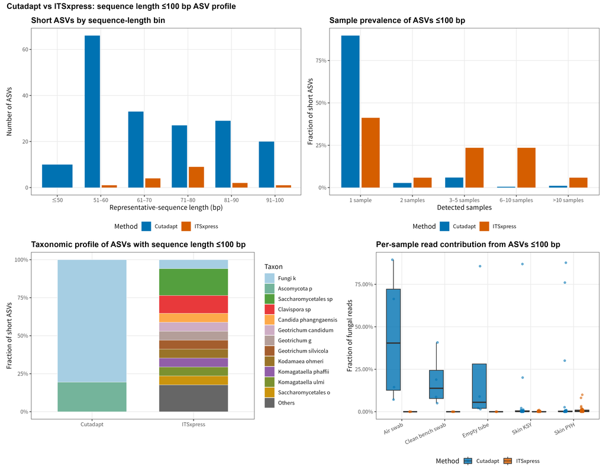

### 4.6.3 SampleID별 짧은 ASV read 기여율

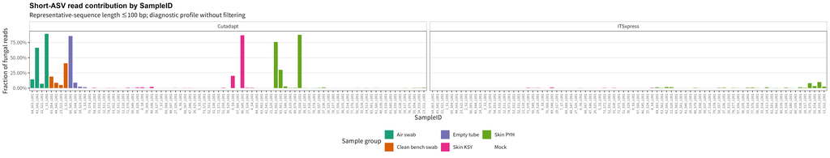

SampleID별 고해상도 PNG 원본

- Cutadapt에서는 길이 100 bp 이하 ASV가 185개(14.2%)이며 전체 fungal reads의 1.3%를 차지함.
- ITSxpress에서는 길이 100 bp 이하 ASV가 17개(1.4%)이며 전체 fungal reads의 0.74%를 차지함.
- 짧다는 이유만으로 contaminant 또는 artifact로 확정하지 않음. 높은 read 기여도, 반복 검출, Nextera motif, control enrichment 및 taxonomy를 함께 판단해야 함.

# 5 5. 결론

- 동일한 83개 sample에서 Cutadapt와 ITSxpress phyloseq object를 생성함.
- 최종 fungal ASV는 Cutadapt 1301개, ITSxpress 1215개로 확인됨.
- 총 fungal read는 Cutadapt 954,579개, ITSxpress 536,398개로 확인됨.
- Paired Aitchison PERMANOVA의 method effect R2는 0.0856, p-value는 0.001로 확인됨.
- Procrustes correlation은 0.95, PROTEST p-value는 0.001로 확인됨.
- 상위 14 Species 중 paired Wilcoxon BH-adjusted p < 0.05인 taxon은 13개로 확인됨.

# 6 6. 한계점 및 향후 분석 예정

- 현재 비교는 `q20_ee22_both_full` 한 parameter 조합에 한정됨.
- Cutadapt와 ITSxpress가 서로 다른 sequence variant를 생성하므로 ASV identity를 직접 일치시키지 않고 동일 taxonomy label의 Species count로 집계하여 비교함.
- 미분류 taxon은 가장 낮은 확인 rank 기반 label로 보완되어 database resolution의 영향을 받음.
- Aitchison PCoA는 rarefaction 없이 수행했으며, pseudocount 0.5 선택에 따른 sensitivity는 수행하지 않음.
- abundance threshold와 singleton removal을 적용하지 않아 low-abundance ASV가 phyloseq object에 유지됨.
- decontam method와 contaminant removal은 적용하지 않음.
- 현재 단계의 paired method test는 library-level 비교이며, Skin biological unit의 반복 PCR 구조에 대한 biological inference를 목적으로 하지 않음.

향후 분석 우선순위:

1. 본 보고서에서 생성한 두 phyloseq object를 입력으로 동일한 Basic analysis를 수행함.
2. Skin sample은 Subject × Site × PCR 구조를 유지하고, control은 source별로 분리하여 두 방법의 alpha, beta 및 taxa 결과를 비교함.
3. Batch balance와 decontam method·threshold가 승인된 이후 두 방법에서 contamination profile의 일관성을 평가함.